# Budweiser IPA Study

Saqib Shahzad & Brian Tobin

```r
#import libraries
library(kableExtra)
library(tidyverse)
library(magrittr)
library(readxl)
library(ggpmisc)
library(class)
library(caret)

#Set the working directory
setwd("C:/Users/btobin/Documents/MDS-6306-Doing-Data-Science-Fall-2019/Unit 8 and 9 Case Study 1")

#Fix the ggplot theme
theme_set(theme_bw())
```

## Question 1

> How many breweries are present in each state?

```r
Beers = read_excel("C:/Users/btobin/Documents/MDS-6306-Doing-Data-Science-Fall-2019/Unit 8 and 9 Case Study 1/Beers.xlsx", sheet = 2)

Beers %>%
  dplyr::count(State) %>%
  mutate(Pct = 100*n/sum(n)) %>%
  rename(Count = n) %>%
  arrange(Count) -> q1

kable(q1, format = "html", align = "lcc", digits = 2) %>%
  kableExtra::kable_styling(full_width = F)
```

| State | Count | Pct |
| --- | --- | --- |
| DC | 1 | 0.18 |
| ND | 1 | 0.18 |
| SD | 1 | 0.18 |
| WV | 1 | 0.18 |
| AR | 2 | 0.36 |
| DE | 2 | 0.36 |
| MS | 2 | 0.36 |
| NV | 2 | 0.36 |
| AL | 3 | 0.54 |
| KS | 3 | 0.54 |
| NH | 3 | 0.54 |
| NJ | 3 | 0.54 |
| TN | 3 | 0.54 |
| HI | 4 | 0.72 |
| KY | 4 | 0.72 |
| NM | 4 | 0.72 |
| SC | 4 | 0.72 |
| UT | 4 | 0.72 |
| WY | 4 | 0.72 |
| IA | 5 | 0.90 |
| ID | 5 | 0.90 |
| LA | 5 | 0.90 |
| NE | 5 | 0.90 |
| RI | 5 | 0.90 |
| OK | 6 | 1.08 |
| AK | 7 | 1.25 |
| GA | 7 | 1.25 |
| MD | 7 | 1.25 |
| CT | 8 | 1.43 |
| ME | 9 | 1.61 |
| MO | 9 | 1.61 |
| MT | 9 | 1.61 |
| VT | 10 | 1.79 |
| AZ | 11 | 1.97 |
| MN | 12 | 2.15 |
| FL | 15 | 2.69 |
| OH | 15 | 2.69 |
| NY | 16 | 2.87 |
| VA | 16 | 2.87 |
| IL | 18 | 3.23 |
| NC | 19 | 3.41 |
| WI | 20 | 3.58 |
| IN | 22 | 3.94 |
| MA | 23 | 4.12 |
| WA | 23 | 4.12 |
| PA | 25 | 4.48 |
| TX | 28 | 5.02 |
| OR | 29 | 5.20 |
| MI | 32 | 5.73 |
| CA | 39 | 6.99 |
| CO | 47 | 8.42 |

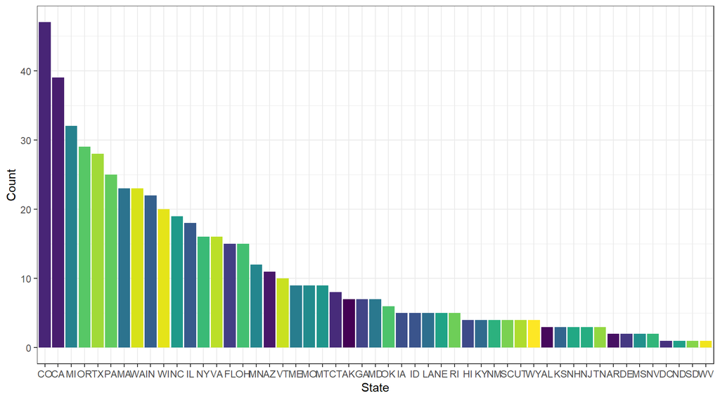

```r
ggplot(q1, aes(reorder(State, -Count), Count, fill = State)) +
  geom_bar(stat = "identity", position = position_dodge2(0.9)) +
  scale_fill_viridis_d() +
  labs(x="State") +
  theme(legend.position = "none", axis.text.x = element_text(size = 9))
```

## Question 2

> Merge beer data with the breweries data. Print the first 6 observations and the last six observations to check the merged file. (RMD only, this does not need to be included in the presentation or the deck.)

## Question 2 Answer

```r
Breweries = read_excel("C:/Users/btobin/Documents/MDS-6306-Doing-Data-Science-Fall-2019/Unit 8 and 9 Case Study 1/Beers.xlsx", sheet = 1)

q2 =
  left_join(Breweries, Beers, by = c("Brewery_id" = "Brew_ID")) %>%
  rename(Beers=Name.x, Breweries=Name.y) %>%
  select(Beer_ID, Beers, Brewery_id, Breweries, everything())


head(q2, 6) %>%
  kable(format="html", align="clclcclcll", digits=2, caption="First six") %>%
  kable_styling(full_width = F)
```

First six

| Beer_ID | Beers | Brewery_id | Breweries | ABV | IBU | Style | Ounces | City | State |
| --- | --- | --- | --- | --- | --- | --- | --- | --- | --- |
| 1436 | Pub Beer | 409 | 10 Barrel Brewing Company | 0.05 | NA | American Pale Lager | 12 | Bend | OR |
| 2265 | Devil’s Cup | 178 | 18th Street Brewery | 0.07 | NA | American Pale Ale (APA) | 12 | Gary | IN |
| 2264 | Rise of the Phoenix | 178 | 18th Street Brewery | 0.07 | NA | American IPA | 12 | Gary | IN |
| 2263 | Sinister | 178 | 18th Street Brewery | 0.09 | NA | American Double / Imperial IPA | 12 | Gary | IN |
| 2262 | Sex and Candy | 178 | 18th Street Brewery | 0.08 | NA | American IPA | 12 | Gary | IN |
| 2261 | Black Exodus | 178 | 18th Street Brewery | 0.08 | NA | Oatmeal Stout | 12 | Gary | IN |

```r
tail(q2, 6) %>%
  kable(format="html", align="clclcclcll", digits=2, caption="Last six") %>%
  kable_styling(full_width = F)
```

Last six

| Beer_ID | Beers | Brewery_id | Breweries | ABV | IBU | Style | Ounces | City | State |
| --- | --- | --- | --- | --- | --- | --- | --- | --- | --- |
| 1035 | Rocky Mountain Oyster Stout | 425 | Wynkoop Brewing Company | 0.08 | NA | American Stout | 12 | Denver | CO |
| 928 | Belgorado | 425 | Wynkoop Brewing Company | 0.07 | 45 | Belgian IPA | 12 | Denver | CO |
| 807 | Rail Yard Ale | 425 | Wynkoop Brewing Company | 0.05 | NA | American Amber / Red Ale | 12 | Denver | CO |
| 620 | B3K Black Lager | 425 | Wynkoop Brewing Company | 0.06 | NA | Schwarzbier | 12 | Denver | CO |
| 145 | Silverback Pale Ale | 425 | Wynkoop Brewing Company | 0.06 | 40 | American Pale Ale (APA) | 12 | Denver | CO |
| 84 | Rail Yard Ale (2009) | 425 | Wynkoop Brewing Company | 0.05 | NA | American Amber / Red Ale | 12 | Denver | CO |

## Question 3

> Address the missing values in each column.

```r
map_dbl(q2, ~is.na(.) %>% sum()) %>%
  enframe(name = "Variable", value = "# Missing") %>%
  arrange(-`# Missing`) %>%
  kable(format="html", align="lc") %>%
  kable_styling(full_width = F)
```

| Variable | # Missing |
| --- | --- |
| IBU | 1005 |
| ABV | 62 |
| Style | 5 |
| Beer_ID | 0 |
| Beers | 0 |
| Brewery_id | 0 |
| Breweries | 0 |
| Ounces | 0 |
| City | 0 |
| State | 0 |

## Question 4

> Compute the median alcohol content and international bitterness unit for each state. Plot a bar chart to compare.

There is no significant difference in reagrds to ABV per state. The state Maine(ME) has the highest median for IBU(61) and Distric of Columbia(DC) and Kentucky(KY) had the highest median ABV of 0.06.

```r
q4 =
  q2 %>%
  group_by(State) %>%
  summarise(
    median_abv = median(ABV, na.rm = T),
    median_ibu = median(IBU, na.rm = T)
    )

q4 %>%
  kable(format="html", align="lcc", digits=2,
        col.names=c("State", "Median ABV", "Median IBU")) %>%
  kable_styling(full_width = F)
```

| State | Median ABV | Median IBU |
| --- | --- | --- |
| AK | 0.06 | 46.0 |
| AL | 0.06 | 43.0 |
| AR | 0.05 | 39.0 |
| AZ | 0.06 | 20.5 |
| CA | 0.06 | 42.0 |
| CO | 0.06 | 40.0 |
| CT | 0.06 | 29.0 |
| DC | 0.06 | 47.5 |
| DE | 0.06 | 52.0 |
| FL | 0.06 | 55.0 |
| GA | 0.06 | 55.0 |
| HI | 0.05 | 22.5 |
| IA | 0.06 | 26.0 |
| ID | 0.06 | 39.0 |
| IL | 0.06 | 30.0 |
| IN | 0.06 | 33.0 |
| KS | 0.05 | 20.0 |
| KY | 0.06 | 31.5 |
| LA | 0.05 | 31.5 |
| MA | 0.05 | 35.0 |
| MD | 0.06 | 29.0 |
| ME | 0.05 | 61.0 |
| MI | 0.06 | 35.0 |
| MN | 0.06 | 44.5 |
| MO | 0.05 | 24.0 |
| MS | 0.06 | 45.0 |
| MT | 0.06 | 40.0 |
| NC | 0.06 | 33.5 |
| ND | 0.05 | 32.0 |
| NE | 0.06 | 35.0 |
| NH | 0.06 | 48.5 |
| NJ | 0.05 | 34.5 |
| NM | 0.06 | 51.0 |
| NV | 0.06 | 41.0 |
| NY | 0.06 | 47.0 |
| OH | 0.06 | 40.0 |
| OK | 0.06 | 35.0 |
| OR | 0.06 | 40.0 |
| PA | 0.06 | 30.0 |
| RI | 0.06 | 24.0 |
| SC | 0.06 | 30.0 |
| SD | 0.06 | NA |
| TN | 0.06 | 37.0 |
| TX | 0.06 | 33.0 |
| UT | 0.04 | 34.0 |
| VA | 0.06 | 42.0 |
| VT | 0.06 | 30.0 |
| WA | 0.06 | 38.0 |
| WI | 0.05 | 19.0 |
| WV | 0.06 | 57.5 |
| WY | 0.05 | 21.0 |

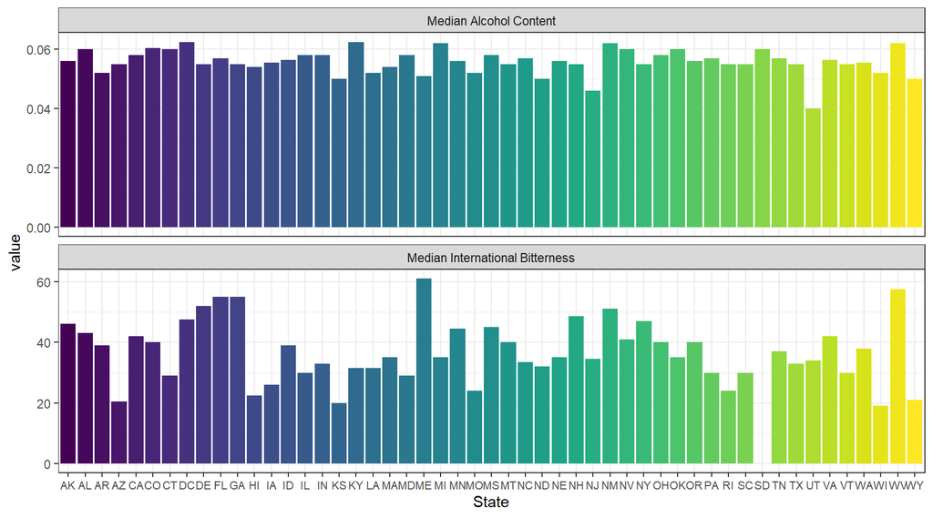

```r
q4 %>%
  gather(key = "key", value = "value", -State) %>%
  ggplot(aes(State, value, fill=State)) +
  geom_bar(stat = "identity", position = position_dodge2(0.9)) +
  scale_fill_viridis_d() +
  facet_wrap(~key, scales = "free_y", ncol = 1,
             labeller =
               labeller(key= c(median_abv='Median Alcohol Content',
                          median_ibu="Median International Bitterness"))) +
  theme(legend.position = "none", axis.text.x = element_text(size=8))
```

## Question 5

> Which state has the maximum alcoholic (ABV) beer? Which state has the most bitter (IBU) beer?

## Question 5 Answer

```r
q4 %>%
  filter(median_abv == max(median_abv, na.rm = T)) %>%
  select(-median_ibu) %>%
  kable(format="html", align="lc", digits=2,
        col.names=c("State", "Median ABV")) %>%
  kable_styling(full_width = F)
```

| State | Median ABV |
| --- | --- |
| DC | 0.06 |
| KY | 0.06 |

```r
q4 %>%
  filter(median_ibu == max(median_ibu, na.rm = T))  %>%
  select(-median_abv) %>%
  kable(format="html", align="lc", digits=2,
        col.names=c("State", "Median IBU")) %>%
  kable_styling(full_width = F)
```

| State | Median IBU |
| --- | --- |
| ME | 61 |

## Question 6

> Comment on the summary statistics and distribution of the ABV variable.

## Question 6 Answer

THe data is right-skewed showing from .04 to .07 has the highest density. The table shows median range split of 50/50. The first quartile show 25% less and 75% high while the third quartile shows 75% less and 25% high.

```r
tibble(
  Stats = summary(q2$ABV) %>% names(),
  Values = summary(q2$ABV) %>% as.vector()
  ) %>%
  kable(format="html", align="lc", digits=3) %>%
  kable_styling(full_width = F)
```

| Stats | Values |
| --- | --- |
| Min. | 0.001 |
| 1st Qu. | 0.050 |
| Median | 0.056 |
| Mean | 0.060 |
| 3rd Qu. | 0.067 |
| Max. | 0.128 |
| NA’s | 62.000 |

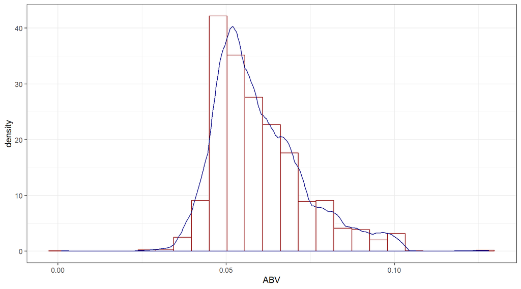

```r
q2 %>%
  ggplot(aes(ABV, ..density..)) +
  geom_histogram(fill="white", color="darkred", bins = 25) +
  geom_density(color="navy", size=0.5, kernel = "epanechnikov")
```

## Question 7

> Is there an apparent relationship between the bitterness of the beer and its alcoholic content? Draw a scatter plot. Make your best judgment of a relationship and EXPLAIN your answer.

## Question 7 Answer

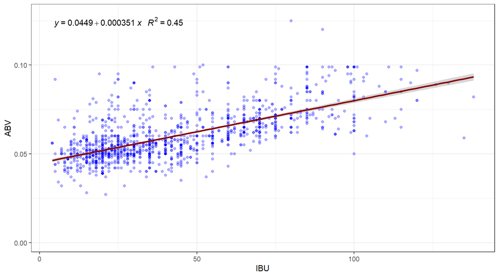

```r
formula <- as.formula(y ~ x)
q2 %>%
  ggplot(aes(IBU, ABV)) +
  geom_point(color="blue", alpha=0.3) +
  geom_smooth(formula = formula, method = "lm", color="darkred") +
  stat_poly_eq(aes(label = paste(..eq.label.., ..rr.label.., sep = "~~~")),
                   formula = formula, parse = TRUE, na.rm = T)
```

```r
lm(ABV ~ IBU, data = q2) %>% summary() %$%
  coefficients %>%
  kable(format="html", align="lc", digits=4, row.names=T) %>%
  kable_styling(full_width = F)
```

|  | Estimate | Std. Error | t value | Pr(>\|t\|) |
| --- | --- | --- | --- | --- |
| (Intercept) | 0.0449 | 5e-04 | 86.7856 | 0 |
| IBU | 0.0004 | 0e+00 | 33.8625 | 0 |

## Question 8

> Budweiser would also like to investigate the difference with respect to IBU and ABV between IPAs (India Pale Ales) and other types of Ale (any beer with Ale in its name other than IPA). You decide to use KNN classification to investigate this relationship. Provide statistical evidence one way or the other. You can of course assume your audience is comfortable with percentages… KNN is very easy to understand conceptually.

## Question 8 Answer

There is twice as much Ale as compared to IPA beer types. Below is various metrics showing the results.

### Create the outcome

```r
q8 =
  q2 %>%
  mutate(
    beer_type =
      ifelse(
        str_to_lower(Beers) %>% str_detect("ipa"), "IPAs",
        ifelse(
          str_to_lower(Beers) %>% str_detect("ale"), "Ale", NA
          )
        ) %>%
      as.factor()
    )

q8 %>%
  dplyr::count(beer_type) %>%
  na.omit() %>%
  mutate(Pct = 100*n/sum(n)) %>%
  rename(Count = n, `Beer Type`=beer_type, Percent=Pct) %>%
  arrange(Count) %>%
  kable(format="html", align="lcc", digits=2, row.names=F) %>%
  kable_styling(full_width = F)
```

| Beer Type | Count | Percent |
| --- | --- | --- |
| IPAs | 336 | 34.67 |
| Ale | 633 | 65.33 |

### KNN without transformation

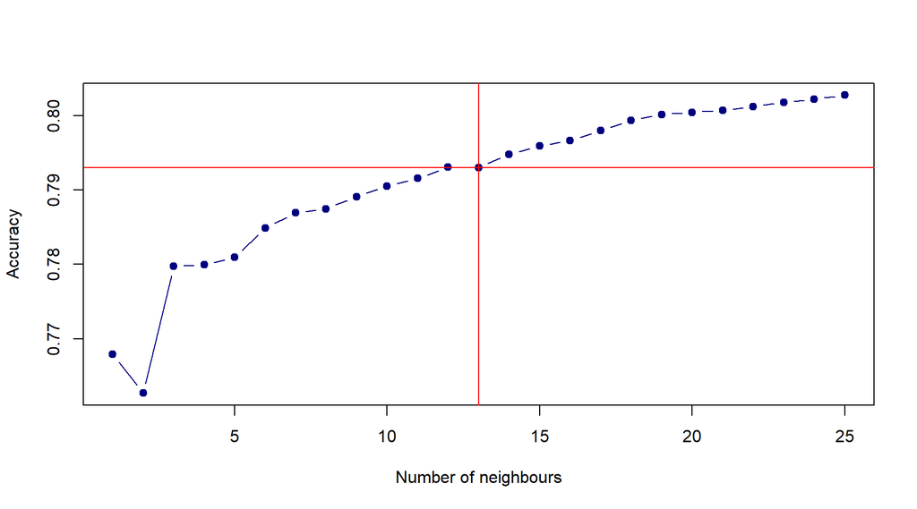

```r
q8_v2 =
  q8 %>%
  select(beer_type, ABV, IBU) %>%
  na.omit() #knn function does not accept missing values

#Select train and test datasets
r = nrow(q8_v2)
p = 0.8
n = as.integer(p*r)
set.seed(198)
iterations = 100
ks = 25
accuracies = matrix(nrow = iterations, ncol = ks)
set.seed(189)
myseeds = runif(iterations) %>% multiply_by(1000) %>% round()

for(j in 1:iterations)
{
  set.seed(myseeds[j])
  index = sample(1:r, n, replace = F)
  test.data = q8_v2[index,]
  train.data = q8_v2[-index,]
  for(i in 1:ks)
  {
    knn(
      train = train.data %>% select(ABV, IBU),
      test = test.data %>% select(ABV, IBU),
      cl = train.data %$% beer_type,
      k = i, prob = F
      ) -> knn_v0
    confMat = confusionMatrix(table(knn_v0, test.data$beer_type))
    accuracies[j,i] = confMat$overall[1]
  }
  #cat(j, "\n")
}

plot(1:ks, colMeans(accuracies), type = "b", lwd=1, pch=19, col="navy",
     xlab = "Number of neighbours", ylab = "Accuracy")
abline(v = 13, col="red")
abline(h = colMeans(accuracies)[13], col="red")
```

```r
avg_acc = colMeans(accuracies)[13]
```

$$Average\,Accuracy = 79.3%$$

### KNN with transformation and normalization

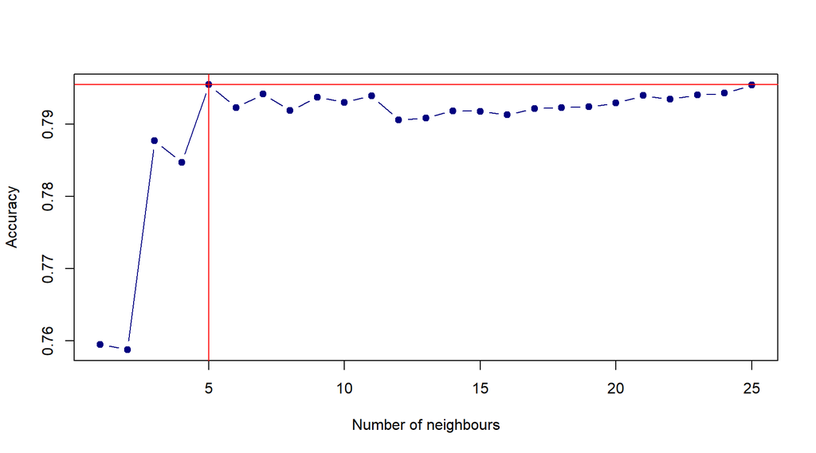

```r
q8_v3 =
  q8_v2 %>%
  mutate(
    ABV = log(ABV+1) %>% scale() %>% as.numeric(),
    IBU = log(IBU) %>% scale() %>% as.numeric()
    )

#Select train and test datasets
r = nrow(q8_v3)
p = 0.8
n = as.integer(p*r)
set.seed(198)
iterations = 100
accuracies = matrix(nrow = iterations, ncol = ks)
ks = 25
set.seed(189)
myseeds = runif(iterations) %>% multiply_by(1000) %>% round()

for(j in 1:iterations)
{
  set.seed(myseeds[j])
  index = sample(1:r, n, replace = F)
  test.data = q8_v3[index,]
  train.data = q8_v3[-index,]
  for(i in 1:ks)
  {
    knn(
      train = train.data %>% select(ABV, IBU),
      test = test.data %>% select(ABV, IBU),
      cl = train.data %$% beer_type,
      k = i, prob = F
      ) -> knn_v0
    confMat = confusionMatrix(table(knn_v0, test.data$beer_type))
    accuracies[j,i] = confMat$overall[1]
  }
  #cat(j, "\n")
}

plot(1:ks, colMeans(accuracies), type = "b", lwd=1, pch=19, col="navy",
     xlab = "Number of neighbours", ylab = "Accuracy")
abline(v = 5, col="red")
abline(h = colMeans(accuracies)[5], col="red")
```

```r
avg_acc = colMeans(accuracies)[5]
```

> The most optimal number of neighbours is **5**

$$Overall\,Accuracy = 79.5%$$

### Alternative: Logistic Regression (without transformation)

We find the approximately the same accuarcy.

```r
q8_v2 =
  q8 %>%
  select(beer_type, ABV, IBU) %>%
  na.omit()

#Select train and test datasets
r = nrow(q8_v2)
p = 0.8
n = as.integer(p*r)
iterations = 100
accuracies = numeric(iterations)
set.seed(189)
myseeds = runif(iterations) %>% multiply_by(1000) %>% round()

for(i in 1:iterations)
{
  set.seed(myseeds[i])
  index = sample(1:r, n, replace = F)
  test.data = q8_v2[index,]
  train.data = q8_v2[-index,]
    glm(
      formula = beer_type ~ ABV + IBU,
      data = q8_v2,
      family = binomial("logit") # logit, probit, cauchit
      ) -> glm_v0
    predicted =
      predict.glm(glm_v0, newdata = test.data, type = "response") %>%
      as.numeric() %>%
      is_weakly_greater_than(0.5) %>%
      ifelse("IPAs", "Ale") %>%
      as.factor()
    confMat = confusionMatrix(table(predicted, test.data$beer_type))
    accuracies[i] = confMat$overall[1]
}

avg_acc = mean(accuracies)
```

$$Overall\,Accuracy = 79.9%$$

## Question 9

```r
us_region =
  tibble(
    State = str_to_upper(state.abb),
    Region = str_to_title(state.region)
    )

q9 =
  left_join(q8, us_region, by="State") %>%
  select(beer_type, ABV, IBU, Ounces, Region) %>%
  na.omit()
```

### Test the association between beer size (ounces variables) and beer type.

```r
#t.test(Ounces ~ beer_type, data = q9, paired=F)
wilcox.test(Ounces ~ beer_type, data = q9, paired=F)
```

```
    Wilcoxon rank sum test with continuity correction

  data:  Ounces by beer_type
  W = 44237, p-value = 0.7595
  alternative hypothesis: true location shift is not equal to 0
```

### Test the association between beer region (ounces variables) and beer type.

```r
count(q9, beer_type, Region) %>%
  group_by(beer_type) %>%
  mutate(Pct = 100*n/sum(n)) %>%
  rename(Count = n) %>%
  arrange(beer_type, Region) %>%
  kable(format = "html", align = "llcc", digits = 2,
        col.names = c("Beer Type", "Region", "Count", "Percent")) %>%
  kable_styling(full_width = F) %>%
  collapse_rows(1)
```

| Beer Type | Region | Count | Percent |
| --- | --- | --- | --- |
| Ale | North Central | 91 | 24.40 |
|  | Northeast | 49 | 13.14 |
|  | South | 66 | 17.69 |
|  | West | 167 | 44.77 |
| IPAs | North Central | 45 | 18.75 |
|  | Northeast | 39 | 16.25 |
|  | South | 40 | 16.67 |
|  | West | 116 | 48.33 |

```r
q9 %$% fisher.test(beer_type, Region)
```

```
    Fisher's Exact Test for Count Data

  data:  beer_type and Region
  p-value = 0.3102
  alternative hypothesis: two.sided
```

### Logistic Regression (without transformation)

```r
q9_v2 =
  q9 %>%
  select(beer_type, ABV, IBU, Region) %>%
  na.omit()

#Select train and test datasets
r = nrow(q9_v2)
p = 0.8
n = as.integer(p*r)
iterations = 100
accuracies = numeric(iterations)
set.seed(189)
myseeds = runif(iterations) %>% multiply_by(1000) %>% round()

for(i in 1:iterations)
{
  set.seed(myseeds[i])
  index = sample(1:r, n, replace = F)
  test.data = q9_v2[index,]
  train.data = q9_v2[-index,]
    glm(
      formula = beer_type ~ ABV + IBU + Region,
      data = q9_v2,
      family = binomial("logit") # logit, probit, cauchit
      ) -> glm_v0
    predicted =
      predict.glm(glm_v0, newdata = test.data, type = "response") %>%
      as.numeric() %>%
      is_weakly_greater_than(0.5) %>%
      ifelse("IPAs", "Ale") %>%
      as.factor()
    confMat = confusionMatrix(table(predicted, test.data$beer_type))
    accuracies[i] = confMat$overall[1]
}

avg_acc = mean(accuracies)
```

$$Overall\,Accuracy = 81.0%$$